# How Linear Regression Works

Ross Woleben

This file is a supplement to an article I wrote on my website explaining Linear Regression, residuals, error, and Least Squares. The article provides additional context to the motivations of these derivations and can be found at https://www.rosswoleben.com/projects/linear-regression .

## The Method of Least Squares

Least squares refers to the finding the smallest possible squared difference between our actual values of y ($y_i$) and our predicted values of y ($\hat y_i$), also referred to as the residual sum of squares (RSS). In Simple Linear Regression, this quantity is defined mathematically as
$$RSS
= \sum_{i=1}^n (y_i - \hat y_i)^2 = \sum_{i=1}^n (y_i - b_0 - b_1x_i)^2$$
Since we want to find the smallest possible RSS, we use calculus to minimize this quantity. We take the partial derivatives with respect to $b_0$ and $b_1$ and set that equation equal to 0 find a local minimum.

$$\frac{\partial RSS}{\partial b_0} =
-2\sum_{i=1}^n (y_i - b_0 - b_1x_i) = 0$$
$$\frac{\partial RSS}{\partial b_1} =
-2\sum_{i=1}^n x_i(y_i - b_0 - b_1x_i) = 0$$
Solving for $b_0$:
$$\sum_{i=1}^n y_i - \sum_{i=1}^n b_0 -
\sum_{i=1}^nb_1x_i = 0$$
$$\sum_{i=1}^n y_i - b_1\sum_{i=1}^nx_i=
b_0*n$$
Divide both sides by n:
$$\bar y - b_1\bar x= b_0$$
Solving for $b_1$:
$$\sum_{i=1}^n x_iy_i - \sum_{i=1}^nb_0 -
\sum_{i=1}^nb_1x_i = 0$$
$$\sum_{i=1}^n x_iy_i = b_1*\sum_{i=1}^nx_i^2 + (\bar y -b_1\bar
x)\sum_{i=1}^nx_i$$
$$\sum_{i=1}^n
x_iy_i = b_1*\sum_{i=1}^nx_i^2 + \bar y \sum_{i=1}^nx_i
-b_1\sum_{i=1}^nx_i * \frac{x_i}{n}$$
Multiply $\frac{n}{n}$ to clean up some terms:
$$\sum_{i=1}^n x_iy_i - \frac{n}{n}\bar y
\sum_{i=1}^nx_i= b_1*\sum_{i=1}^nx_i^2 -\frac{n}{n}b_1\sum_{i=1}^nx_i *
\frac{x_i}{n}$$
$$b_1 =
\frac{\sum_{i=1}^n x_iy_i - n\bar {xy}}{\sum_{i=1}^nx_i^2-n\bar x^2} =
\frac{\sum_{i=1}^n (x_i-\bar x) (y_i-\bar y)}{\sum_{i=1}^n(x_i-\bar
x)^2} = \frac{Cov(x,y)}{Var(x)}$$
*Note: Cov(x,y) and Var(x) represent the sample covariance of x and y and the sample variance of x, respectively.

### Least Squares Estimate Example Calculations

Now that we know how to get $b_1$ and $b_0$, let’s use some artificial data to calculate some estimates

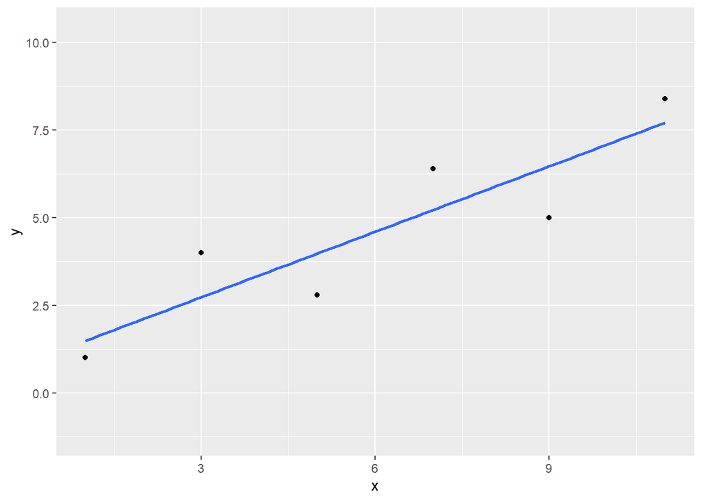

```r
#Mean of x = 6
x <- c(1,3,5,7,9,11)
#Mean of y = 4.6
y <- c(1,4,2.8, 6.4, 5, 8.4)
df <- data.frame(x=x,y=y)
ggplot(df, aes(x=x,y=y)) + geom_point() + geom_smooth(method = 'lm', fill = NA)
```

```r
cov(x,y)
```

```
## [1] 8.72
```

```r
var(x)
```

```
## [1] 14
```

```r
cov(x,y)/var(x)
```

```
## [1] 0.6228571
```

They are! With this data $b_1 = 8.72/14 = .6228571$; $b_0 = \bar y - b_1\bar x = 4.6 - .6228571*6 = .8628574$. Lets check if these values match up with the output of a linear regression performed with R:

```r
lm(y~x)$coefficients
```

```
## (Intercept)           x
##   0.8628571   0.6228571
```

Awesome, our coefficients match! The lm command also uses least squares.

## Interpretation

One of the reasons why linear regression is so popular is because of its interpretability.

```r
summary(lm(y~x))
```

```
##
## Call:
## lm(formula = y ~ x)
##
## Residuals:
##       1       2       3       4       5       6
## -0.4857  1.2686 -1.1771  1.1771 -1.4686  0.6857
##
## Coefficients:
##             Estimate Std. Error t value Pr(>|t|)
## (Intercept)   0.8629     1.1105   0.777    0.481
## x             0.6229     0.1608   3.873    0.018 *
## ---
## Signif. codes:  0 '***' 0.001 '**' 0.01 '*' 0.05 '.' 0.1 ' ' 1
##
## Residual standard error: 1.346 on 4 degrees of freedom
## Multiple R-squared:  0.7894, Adjusted R-squared:  0.7368
## F-statistic:    15 on 1 and 4 DF,  p-value: 0.01795
```

For this specific data, as x increases by 1, y is expected to increase by .6229 and when x equals 0, y is expected to equal .8629.

## Multiple Linear Regression

Lastly I wanted to show the matrix representation of Linear Regression. I actually introduced the matrix expression for regression before I introduced simple linear regression. This isn’t used that often in SLR, but when you want to use more than one predictor (multiple linear regression), matrix notation is necessary. Here is what these matrices look like:
$$Y=X\beta+\epsilon \\ Y
= \begin{bmatrix}y_1 \\ y_2 \\ \vdots \\ y_n \end{bmatrix};
X =\begin{bmatrix}1&x_{11}&\cdots&x_{1p} \\
1&x_{21}&\cdots&x_{2p} \\
\vdots&\vdots&\ddots&\vdots \\
1&x_{n1}&\cdots&x_{np} \end{bmatrix};
\beta = \begin{bmatrix}\beta_0 \\ \beta_1 \\ \vdots \\ \beta_p
\end{bmatrix};
\epsilon = \begin{bmatrix}\epsilon_1 \\ \epsilon_2 \\ \vdots \\
\epsilon_n \end{bmatrix}$$

The math behind multiple linear regression is not nearly as beginner-friendly as SLR. Doing manual calculations is far less intuitive - both mathematically and graphically - so I’ll just do a higher level derivation to show how it extends the concepts of SLR with a small amount of additional complexity.

In multiple linear regression, the predicted value of y can no longer be expressed as $\hat y_i = b_0 + b_1x_1$, since we have more than one predictor, we need to adjust this to include more than one x. In general, predicted value can be expressed as $\hat y_i = b_0 + b_1x_{1i} + b_2x_{2i}+ ... + b_px_{pi}$, where p is the number of predictors used in the regression. The same procedure of least squares is still valid:
$$RSS = \sum_{i=1}^n (y_i - \hat
y_i)^2 = \sum_{i=1}^n (y_i - b_0 - b_1x_{1i} - b_2x_{2i}- ... -
b_px_{pi})^2$$
We still want to take the partial derivative of RSS with respect to each parameter. Unfortunately though, this generates a system of p+1 equations with p+1 unknowns,
$$\frac{\partial RSS}{\partial b_0} =
-2\sum_{i=1}^n (y_i - b_0 - b_1x_{1i} - b_2x_{2i}- ... - b_px_{pi}) =
0$$
$$\frac{\partial RSS}{\partial
b_1} = -2\sum_{i=1}^n x_{1i}(y_i - b_0 - b_1x_{1i} - b_2x_{2i}- ... -
b_px_{pi}) = 0$$
…
$$\frac{\partial
RSS}{\partial b_p} = -2\sum_{i=1}^n x_{pi}(y_i - b_0 - b_1x_{1i} -
b_2x_{2i}- ... - b_px_{pi}) = 0$$
Solving this system is still possible, but it may not be closed form like it was in the case of simple linear regression.

See article at https://www.rosswoleben.com/projects/linear-regression for further conclusion.